# HarvardX PH125.9x - Data Science: Capstone

# Document Governance

- Title: **Wine quality**
- Code :**Not Applicable**
- Type : Capstone project
- Date of issue :12/05/2021
- Revision number : 00
- Status : Released

## Document creation and review

| Name | Contact | Participation | Date |
| --- | --- | --- | --- |
| Helio Guedes De Brito Neto | guedeshelio@hotmail.com | Author | 12/05/2021 |

## Abbreviations & Acronyms

| Abbreviation | Meaning |
| --- | --- |
| cp | Complexity parameter |
| EDA | Exploratory Data Analysis |
| FN | False Negative |
| FP | False positive |
| OOB | Out of bag re-sampling |
| Knn | K nearest neighbor |
| KPI | Key Performance Indicator |
| RMSE | Root Mean Square Error |
| TN | True Negative |
| TP | True Positive |

# Executive Summary

The document was built in R studio environment and originally saved as a R notebook.

A data set from UCI machine learned database repository was chosen following the requested criteria set by the course organizers.

Data intake and first transformation were done in dedicated script and results loaded into this notebook

The objective of this project was to create a prediction model for wine quality, based on the phisycochemical properties.

Due to the nature of the response, classification models were selected, processed and fine tuned in a training data set and validated in a testing data set. The validation results compared to define the best model.

The random forest model, with a minimum of fine tuning presented the best result in terms of overall accuracy (around 70%) and Kappa index (around 50%), making an improvement of 25% in performance when compared to the baseline. Despite of the satisfactory results the models was not able to correct classify extremes, due to the unbalanced data base.

The top 5 predictors for the the wine quality were in line with the EDA

1. Alcohol
2. Density
3. Volatile acidity
4. Total sulfur
5. Chlorides

# 1 Introduction

This document is the final deliverable for HarvardX - Introduction to Data Science course. The objective of the report is to demonstrate how the fundamentals of Data Science are applied in real cases based on an new data set (data set not used throughout the course). The chosen data is imported directly from the web repository in a dedicated R script and refers to the quality of red and white “Vinho Verde”, produced in Minho region, Portugal.

# 2 Overview

Vinho Verde (green wine) refers to Portuguese wine produced in the historic Minho province in the far north of the country. Vinho Verde is not a grape variety but related to the region where the vines are located and the wine is released from 3 to 6 months after the grapes are harvested. The region where the wine is produced was demarcated in 1908. The wine can be red, white or rose and usually consumed soon after bottling. It is a light and fresh wine with alcohol content varying from 11.5 to 14%.

More information about Vinho Verde can be found in English by following the link: [Vinho Verde information](https://en.wikipedia.org/wiki/Vinho_Verde)

## 2.1 Objective

Predict wine quality based on the wine type (red / white) and the physicochemical characteristics

## 2.2 Method / Analysis

The workflow will follow the typical Data Science process is the following sequence:

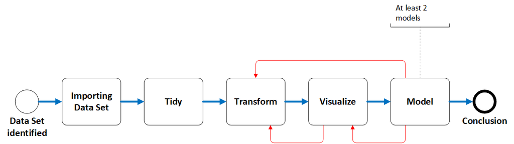

Data Science project workflow

1. Importing
- Data is imported from the web repository and loaded in R environment to be processed
2. Exploratory Data Analysis
- Clean ,Tidy and Transform (Wrangling)
  - Data shall be stored in a consistent structure. This allows the efforts to be dedicated to the data analysis. Transformation in the data is often required to improve analysis
- Visualization
  - Visualization helps the analysis to spot issues and trigger further questions towards the objective
3. Modelling and Machine learning
- At least 2 models to predict quality the results will be developed

Temporary files will be removed after usage to maintain the variables environment lean.

# 3 Exploratory Data Analysis (EDA)

## 3.1 Data set overview

There are two different data sets available, one for red wine and one for white wine, where physicochemical properties (predictors) are listed together with a quality assessment of the wine based on sensory analysis done by 3 experts (response).The listed response is the average of the expert assessment. The wines are classified from 0 (very bad) to 10 (excellent)

It is observed that both data sets are complete (no Na’s) however are not balanced in terms of wine type. The red wine data set has 1599 observations while the white wine data set has 4898.

Both data sets have the same listed predictors making it easier to merge them in a bigger data set to include wine type as a predictor.

### 3.1.1 Red wine data set structure

```r
#load the data frame
load("red_wine.RData")
# Head of data set
kable(head(red_wine),align="l", "html", booktabs=TRUE, caption = "Extract of red wine data set")%>%
  kable_styling(bootstrap_options ="striped", full_width = TRUE, position = "center", fixed_thead = T, font_size = 10)%>%
  row_spec(row=0,angle=0,color="steelblue", bold=T)
```

Extract of red wine data set

| fixed.acidity | volatile.acidity | citric.acid | residual.sugar | chlorides | free.sulfur.dioxide | total.sulfur.dioxide | density | pH | sulphates | alcohol | quality |
| --- | --- | --- | --- | --- | --- | --- | --- | --- | --- | --- | --- |
| 7.4 | 0.70 | 0.00 | 1.9 | 0.076 | 11 | 34 | 0.9978 | 3.51 | 0.56 | 9.4 | 5 |
| 7.8 | 0.88 | 0.00 | 2.6 | 0.098 | 25 | 67 | 0.9968 | 3.20 | 0.68 | 9.8 | 5 |
| 7.8 | 0.76 | 0.04 | 2.3 | 0.092 | 15 | 54 | 0.9970 | 3.26 | 0.65 | 9.8 | 5 |
| 11.2 | 0.28 | 0.56 | 1.9 | 0.075 | 17 | 60 | 0.9980 | 3.16 | 0.58 | 9.8 | 6 |
| 7.4 | 0.70 | 0.00 | 1.9 | 0.076 | 11 | 34 | 0.9978 | 3.51 | 0.56 | 9.4 | 5 |
| 7.4 | 0.66 | 0.00 | 1.8 | 0.075 | 13 | 40 | 0.9978 | 3.51 | 0.56 | 9.4 | 5 |

```r
# Structure of the data set
str(red_wine)
```

```
'data.frame':   1599 obs. of  12 variables:
 $ fixed.acidity       : num  7.4 7.8 7.8 11.2 7.4 7.4 7.9 7.3 7.8 7.5 ...
 $ volatile.acidity    : num  0.7 0.88 0.76 0.28 0.7 0.66 0.6 0.65 0.58 0.5 ...
 $ citric.acid         : num  0 0 0.04 0.56 0 0 0.06 0 0.02 0.36 ...
 $ residual.sugar      : num  1.9 2.6 2.3 1.9 1.9 1.8 1.6 1.2 2 6.1 ...
 $ chlorides           : num  0.076 0.098 0.092 0.075 0.076 0.075 0.069 0.065 0.073 0.071 ...
 $ free.sulfur.dioxide : num  11 25 15 17 11 13 15 15 9 17 ...
 $ total.sulfur.dioxide: num  34 67 54 60 34 40 59 21 18 102 ...
 $ density             : num  0.998 0.997 0.997 0.998 0.998 ...
 $ pH                  : num  3.51 3.2 3.26 3.16 3.51 3.51 3.3 3.39 3.36 3.35 ...
 $ sulphates           : num  0.56 0.68 0.65 0.58 0.56 0.56 0.46 0.47 0.57 0.8 ...
 $ alcohol             : num  9.4 9.8 9.8 9.8 9.4 9.4 9.4 10 9.5 10.5 ...
 $ quality             : int  5 5 5 6 5 5 5 7 7 5 ...
```

```r
# Number of NA's
sum(is.na(red_wine))
```

```
[1] 0
```

### 3.1.2 White wine data set structure

```r
# Load red wine data set
load(file="white_wine.RData")

# Head of data set
kable(head(white_wine),align="l", "html", booktabs=TRUE, caption = "Extract of white wine data set")%>%
  kable_styling(bootstrap_options ="striped", full_width = TRUE, position = "center", fixed_thead = T, font_size = 10)%>%
  row_spec(row=0,angle=0,color="steelblue", bold=T)
```

Extract of white wine data set

| fixed.acidity | volatile.acidity | citric.acid | residual.sugar | chlorides | free.sulfur.dioxide | total.sulfur.dioxide | density | pH | sulphates | alcohol | quality |
| --- | --- | --- | --- | --- | --- | --- | --- | --- | --- | --- | --- |
| 7.0 | 0.27 | 0.36 | 20.7 | 0.045 | 45 | 170 | 1.0010 | 3.00 | 0.45 | 8.8 | 6 |
| 6.3 | 0.30 | 0.34 | 1.6 | 0.049 | 14 | 132 | 0.9940 | 3.30 | 0.49 | 9.5 | 6 |
| 8.1 | 0.28 | 0.40 | 6.9 | 0.050 | 30 | 97 | 0.9951 | 3.26 | 0.44 | 10.1 | 6 |
| 7.2 | 0.23 | 0.32 | 8.5 | 0.058 | 47 | 186 | 0.9956 | 3.19 | 0.40 | 9.9 | 6 |
| 7.2 | 0.23 | 0.32 | 8.5 | 0.058 | 47 | 186 | 0.9956 | 3.19 | 0.40 | 9.9 | 6 |
| 8.1 | 0.28 | 0.40 | 6.9 | 0.050 | 30 | 97 | 0.9951 | 3.26 | 0.44 | 10.1 | 6 |

```r
# Structure of the data set
str(white_wine)
```

```
'data.frame':   4898 obs. of  12 variables:
 $ fixed.acidity       : num  7 6.3 8.1 7.2 7.2 8.1 6.2 7 6.3 8.1 ...
 $ volatile.acidity    : num  0.27 0.3 0.28 0.23 0.23 0.28 0.32 0.27 0.3 0.22 ...
 $ citric.acid         : num  0.36 0.34 0.4 0.32 0.32 0.4 0.16 0.36 0.34 0.43 ...
 $ residual.sugar      : num  20.7 1.6 6.9 8.5 8.5 6.9 7 20.7 1.6 1.5 ...
 $ chlorides           : num  0.045 0.049 0.05 0.058 0.058 0.05 0.045 0.045 0.049 0.044 ...
 $ free.sulfur.dioxide : num  45 14 30 47 47 30 30 45 14 28 ...
 $ total.sulfur.dioxide: num  170 132 97 186 186 97 136 170 132 129 ...
 $ density             : num  1.001 0.994 0.995 0.996 0.996 ...
 $ pH                  : num  3 3.3 3.26 3.19 3.19 3.26 3.18 3 3.3 3.22 ...
 $ sulphates           : num  0.45 0.49 0.44 0.4 0.4 0.44 0.47 0.45 0.49 0.45 ...
 $ alcohol             : num  8.8 9.5 10.1 9.9 9.9 10.1 9.6 8.8 9.5 11 ...
 $ quality             : int  6 6 6 6 6 6 6 6 6 6 ...
```

```r
# Number of NA's
sum(is.na(white_wine))
```

```
[1] 0
```

### 3.1.3 Predictors Overview

Both data sets will be joined for further data manipulation, transformation and visualization. For that a new variable called “wine_type” will be created in each data set. This data combination is done in a R script and loaded into the notebook.

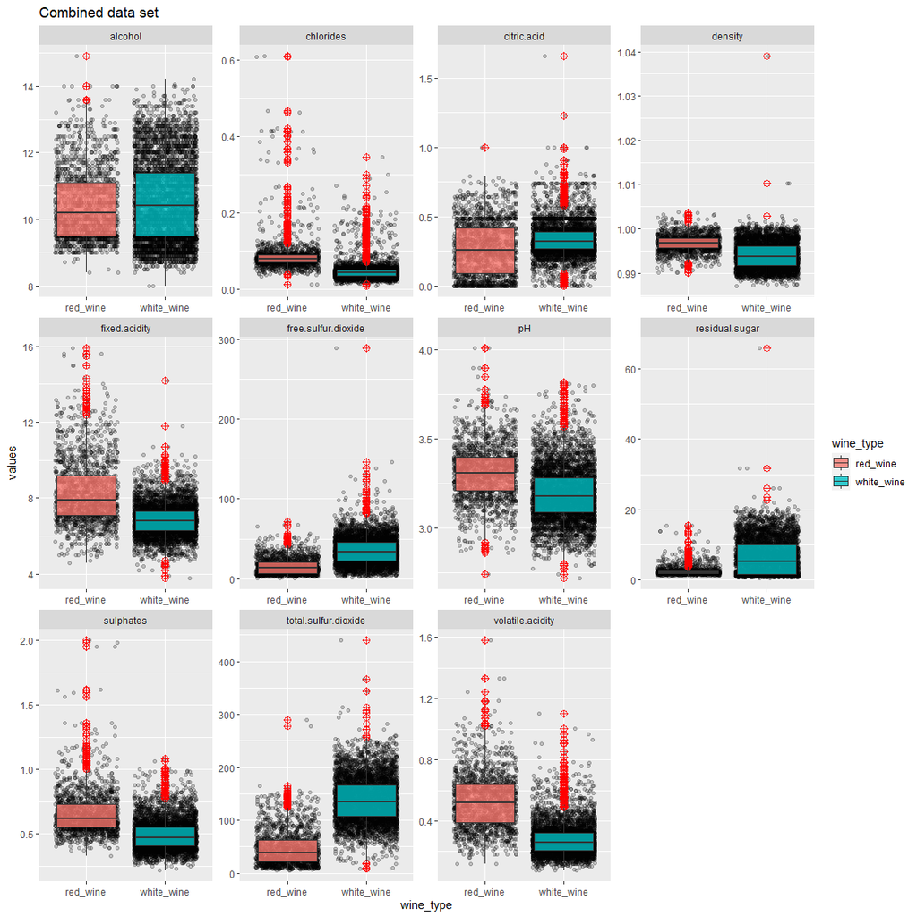

```r
load(file="wine.RData")

# To visualize all the charts at one the data will be put in a long format

wine%>%
  pivot_longer(names_to = "variables",values_to="values", col=c(-quality,-wine_type))%>%
  ggplot(aes(x= wine_type,y=values))+
  geom_jitter(alpha=0.2)+
  geom_boxplot(aes(fill= wine_type), alpha=0.8, outlier.colour = "red",outlier.size = 3, outlier.shape = 10)+
  facet_wrap(~variables,scale="free")+
  ggtitle("Combined data set")
```

The combined box-plots make evident that some of the predictors are not normally distributed with the presence of possible outliers are which imposes skweness to the distribution. The presence of outliers can be an issue for modelling. Depending on the chosen machine learning technique further data manipulation may be required.

**Outliers won’t be removed from the data set at this stage.**

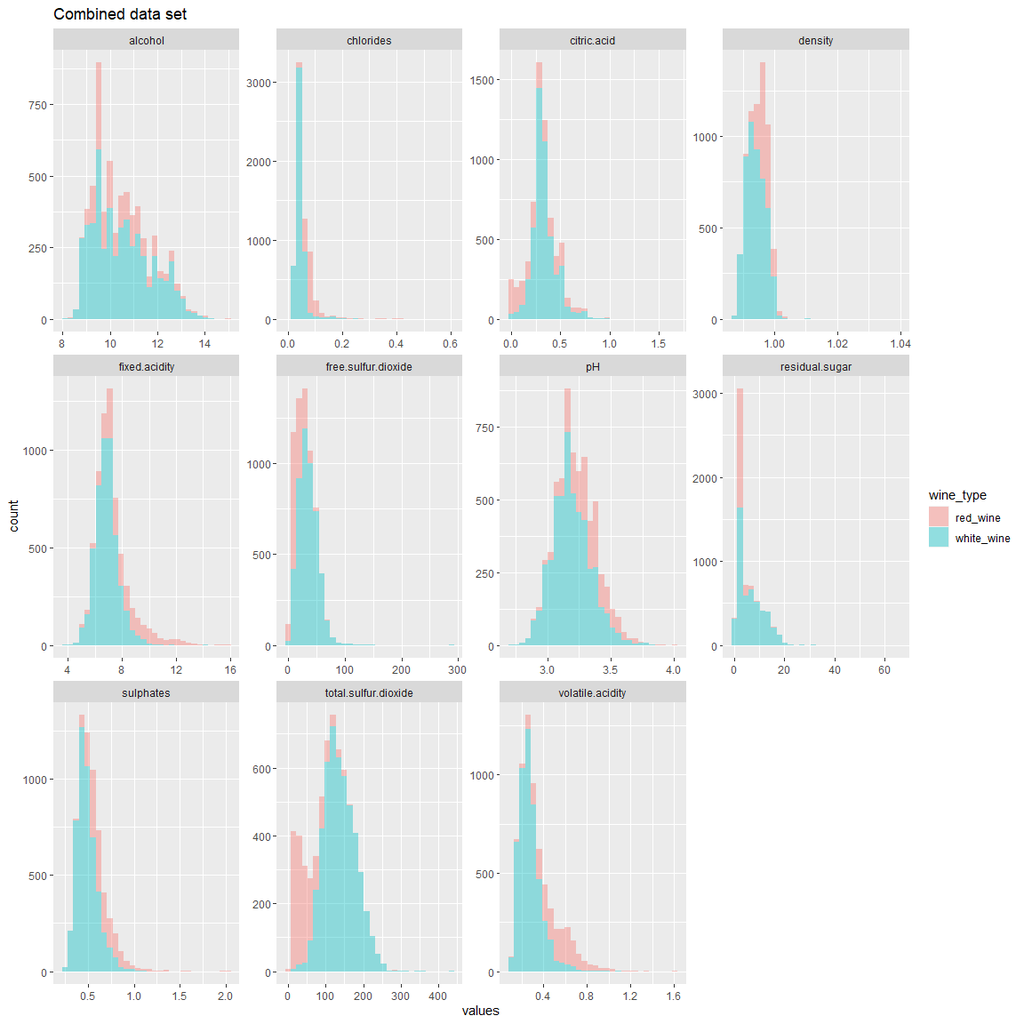

```r
# To visualize all the charts at one the data will be put in a long format

wine%>%
  pivot_longer(names_to = "variables",values_to="values", col=c(-quality,-wine_type))%>%
  ggplot(aes(x=values))+
  geom_histogram(aes(fill=wine_type), bins=30, alpha=0.4)+
  facet_wrap(~variables,scale="free")+
  ggtitle("Combined data set")
```

The shape of the distribution for the predictors from red and white wines are similar in most of the cases

```r
#summary for combined data set
summary(wine)
```

```
 fixed.acidity    volatile.acidity  citric.acid     residual.sugar
 Min.   : 3.800   Min.   :0.0800   Min.   :0.0000   Min.   : 0.600
 1st Qu.: 6.400   1st Qu.:0.2300   1st Qu.:0.2500   1st Qu.: 1.800
 Median : 7.000   Median :0.2900   Median :0.3100   Median : 3.000
 Mean   : 7.215   Mean   :0.3397   Mean   :0.3186   Mean   : 5.443
 3rd Qu.: 7.700   3rd Qu.:0.4000   3rd Qu.:0.3900   3rd Qu.: 8.100
 Max.   :15.900   Max.   :1.5800   Max.   :1.6600   Max.   :65.800
   chlorides       free.sulfur.dioxide total.sulfur.dioxide
 Min.   :0.00900   Min.   :  1.00      Min.   :  6.0
 1st Qu.:0.03800   1st Qu.: 17.00      1st Qu.: 77.0
 Median :0.04700   Median : 29.00      Median :118.0
 Mean   :0.05603   Mean   : 30.53      Mean   :115.7
 3rd Qu.:0.06500   3rd Qu.: 41.00      3rd Qu.:156.0
 Max.   :0.61100   Max.   :289.00      Max.   :440.0
    density             pH          sulphates         alcohol
 Min.   :0.9871   Min.   :2.720   Min.   :0.2200   Min.   : 8.00
 1st Qu.:0.9923   1st Qu.:3.110   1st Qu.:0.4300   1st Qu.: 9.50
 Median :0.9949   Median :3.210   Median :0.5100   Median :10.30
 Mean   :0.9947   Mean   :3.219   Mean   :0.5313   Mean   :10.49
 3rd Qu.:0.9970   3rd Qu.:3.320   3rd Qu.:0.6000   3rd Qu.:11.30
 Max.   :1.0390   Max.   :4.010   Max.   :2.0000   Max.   :14.90
    quality           wine_type
 Min.   :3.000   red_wine  :1599
 1st Qu.:5.000   white_wine:4898
 Median :6.000
 Mean   :5.818
 3rd Qu.:6.000
 Max.   :9.000
```

```r
# summary for the red wine
summary(red_wine)
```

```
 fixed.acidity   volatile.acidity  citric.acid    residual.sugar
 Min.   : 4.60   Min.   :0.1200   Min.   :0.000   Min.   : 0.900
 1st Qu.: 7.10   1st Qu.:0.3900   1st Qu.:0.090   1st Qu.: 1.900
 Median : 7.90   Median :0.5200   Median :0.260   Median : 2.200
 Mean   : 8.32   Mean   :0.5278   Mean   :0.271   Mean   : 2.539
 3rd Qu.: 9.20   3rd Qu.:0.6400   3rd Qu.:0.420   3rd Qu.: 2.600
 Max.   :15.90   Max.   :1.5800   Max.   :1.000   Max.   :15.500
   chlorides       free.sulfur.dioxide total.sulfur.dioxide
 Min.   :0.01200   Min.   : 1.00       Min.   :  6.00
 1st Qu.:0.07000   1st Qu.: 7.00       1st Qu.: 22.00
 Median :0.07900   Median :14.00       Median : 38.00
 Mean   :0.08747   Mean   :15.87       Mean   : 46.47
 3rd Qu.:0.09000   3rd Qu.:21.00       3rd Qu.: 62.00
 Max.   :0.61100   Max.   :72.00       Max.   :289.00
    density             pH          sulphates         alcohol
 Min.   :0.9901   Min.   :2.740   Min.   :0.3300   Min.   : 8.40
 1st Qu.:0.9956   1st Qu.:3.210   1st Qu.:0.5500   1st Qu.: 9.50
 Median :0.9968   Median :3.310   Median :0.6200   Median :10.20
 Mean   :0.9967   Mean   :3.311   Mean   :0.6581   Mean   :10.42
 3rd Qu.:0.9978   3rd Qu.:3.400   3rd Qu.:0.7300   3rd Qu.:11.10
 Max.   :1.0037   Max.   :4.010   Max.   :2.0000   Max.   :14.90
    quality
 Min.   :3.000
 1st Qu.:5.000
 Median :6.000
 Mean   :5.636
 3rd Qu.:6.000
 Max.   :8.000
```

```r
#summary for the white wine
summary(white_wine)
```

```
 fixed.acidity    volatile.acidity  citric.acid     residual.sugar
 Min.   : 3.800   Min.   :0.0800   Min.   :0.0000   Min.   : 0.600
 1st Qu.: 6.300   1st Qu.:0.2100   1st Qu.:0.2700   1st Qu.: 1.700
 Median : 6.800   Median :0.2600   Median :0.3200   Median : 5.200
 Mean   : 6.855   Mean   :0.2782   Mean   :0.3342   Mean   : 6.391
 3rd Qu.: 7.300   3rd Qu.:0.3200   3rd Qu.:0.3900   3rd Qu.: 9.900
 Max.   :14.200   Max.   :1.1000   Max.   :1.6600   Max.   :65.800
   chlorides       free.sulfur.dioxide total.sulfur.dioxide
 Min.   :0.00900   Min.   :  2.00      Min.   :  9.0
 1st Qu.:0.03600   1st Qu.: 23.00      1st Qu.:108.0
 Median :0.04300   Median : 34.00      Median :134.0
 Mean   :0.04577   Mean   : 35.31      Mean   :138.4
 3rd Qu.:0.05000   3rd Qu.: 46.00      3rd Qu.:167.0
 Max.   :0.34600   Max.   :289.00      Max.   :440.0
    density             pH          sulphates         alcohol
 Min.   :0.9871   Min.   :2.720   Min.   :0.2200   Min.   : 8.00
 1st Qu.:0.9917   1st Qu.:3.090   1st Qu.:0.4100   1st Qu.: 9.50
 Median :0.9937   Median :3.180   Median :0.4700   Median :10.40
 Mean   :0.9940   Mean   :3.188   Mean   :0.4898   Mean   :10.51
 3rd Qu.:0.9961   3rd Qu.:3.280   3rd Qu.:0.5500   3rd Qu.:11.40
 Max.   :1.0390   Max.   :3.820   Max.   :1.0800   Max.   :14.20
    quality
 Min.   :3.000
 1st Qu.:5.000
 Median :6.000
 Mean   :5.878
 3rd Qu.:6.000
 Max.   :9.000
```

## 3.2 Response Overview

The behavior of the response variable , which in many cases can be considered as a process KPI, is important for the further steps. Depending on the choice of the model, some transformations also in the response variable may be required.

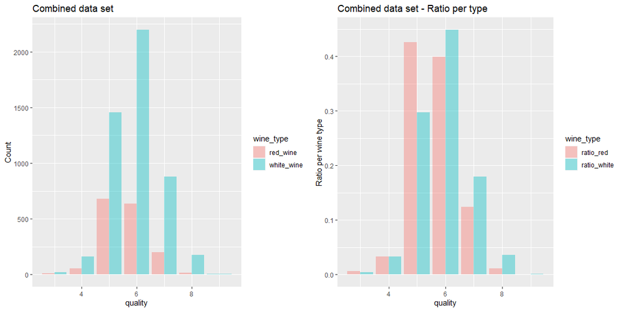

```r
# Create a bar plot to visualize response by count
a <-wine%>%
  group_by(quality,wine_type)%>%
  summarise(Count=n())%>%
  ggplot(aes(x=quality,y=Count))+
  geom_col(aes(fill=wine_type),position="dodge", alpha=0.4)+
  ggtitle("Combined data set")

total_red <- nrow(red_wine)
total_white <- nrow(white_wine)

# Create a summary with percentual by response and type
wine_summary<- wine%>%
  select(wine_type,quality)%>%
  group_by(quality,wine_type)%>%
  summarise(Count=n())%>%
  pivot_wider(names_from = wine_type,values_from=Count)%>%
  mutate(ratio_red =red_wine/total_red,
         ratio_white=white_wine/total_white)%>%
  select(quality,red_wine,ratio_red,white_wine,ratio_white)

b<- wine_summary %>%
  select(quality,ratio_red,ratio_white)%>%
  pivot_longer(col=c(ratio_red,ratio_white), names_to="wine_type",
               values_to="ratio")%>%
  ggplot(aes(x=quality,y=ratio))+
  geom_col(aes(fill=wine_type),position="dodge", alpha=0.4)+
  ggtitle("Combined data set - Ratio per type")+
  ylab("Ratio per wine type")

# Plot results
grid.arrange(a,b,ncol=2)
```

```r
# Print table
kable(wine_summary,align="l", "html", booktabs=TRUE, caption = "Response Distribution by whine type")%>%
  kable_styling(bootstrap_options ="striped", full_width = TRUE, position = "center", fixed_thead = T, font_size = 10)%>%
  row_spec(row=0,angle=0,color="steelblue", bold=T)
```

Response Distribution by whine type

| quality | red_wine | ratio_red | white_wine | ratio_white |
| --- | --- | --- | --- | --- |
| 3 | 10 | 0.0062539 | 20 | 0.0040833 |
| 4 | 53 | 0.0331457 | 163 | 0.0332789 |
| 5 | 681 | 0.4258912 | 1457 | 0.2974684 |
| 6 | 638 | 0.3989994 | 2198 | 0.4487546 |
| 7 | 199 | 0.1244528 | 880 | 0.1796652 |
| 8 | 18 | 0.0112570 | 175 | 0.0357289 |
| 9 | NA | NA | 5 | 0.0010208 |

```r
# remove temporary files
rm(a,b,wine_summary,total_red,total_white)
```

The bar plot indicates that white wines tends to be better graded than red wines, however this can be linked to the unbalanced distribution between wine types.

No extreme grades are present in the data set (0,1,2 & 10).This imposes some restrictions to the models, which will have narrower boundaries (from class 3 to class 9).

It is also interesting to notice that the classes in the response variable are not balanced.

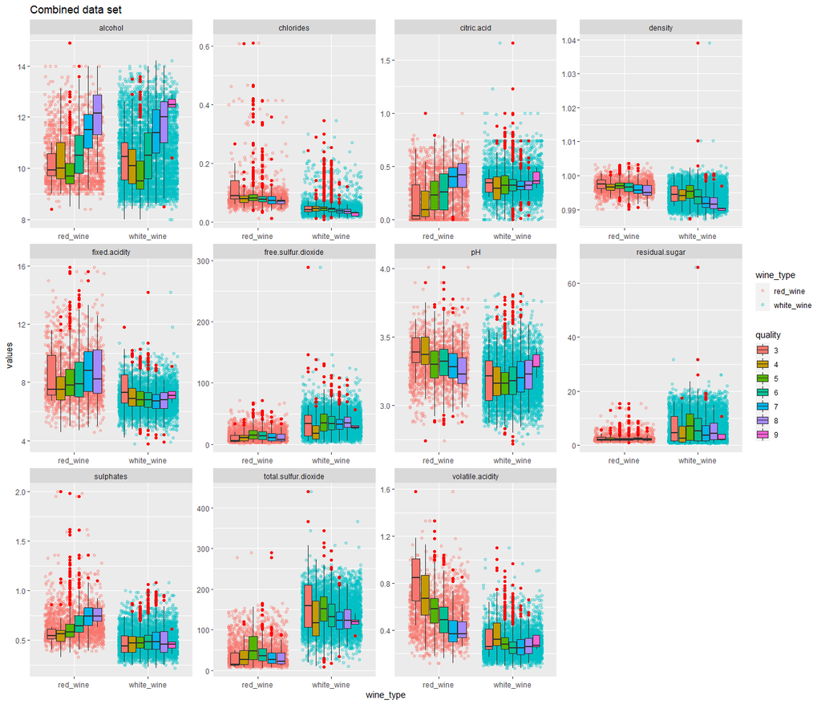

```r
wine%>%
  pivot_longer(names_to = "variables",values_to="values", col=c(-quality,-wine_type))%>%
  mutate(quality=factor(quality))%>%
  ggplot(aes(y=values,x=wine_type))+
  geom_jitter(alpha=0.3, aes(colour=wine_type))+
  geom_boxplot(aes(fill=quality), outlier.colour = "red")+
  facet_wrap(~variables,scale="free")+
  ggtitle("Combined data set")
```

Analyzing the charts it is possible to spot some possible tendencies:

- Wines with higher alcoholic levels seem to be better classified for both types of wine
- Wines with lower density levels seem to be better classified (High correlation with alcohol levels) for both types of wines
- Wines with lower chlorides levels seem to be better classified
- red wines with higher levels of citric acid seem to be better correlated
- red wines with higher levels of sulfates seem to better correlated

If the task was to determine the type of wine based on the chemical composition,the sulfur dioxide would play an important role

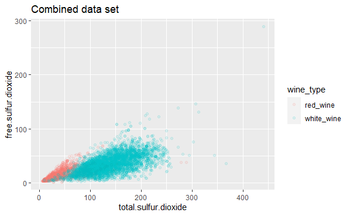

```r
wine%>%
  mutate(quality=factor(quality))%>%
  ggplot(aes(y=free.sulfur.dioxide,x=total.sulfur.dioxide))+
  geom_jitter(alpha=0.1, aes(colour=wine_type))+
  ggtitle("Combined data set")
```

## 3.3 Correlation between predictors and response

For this exercise, the response will be considered as numeric (not classification), just to give some indication where possible correlation may exist.

### 3.3.1 Linear Bi-Variate correlation : Pearson

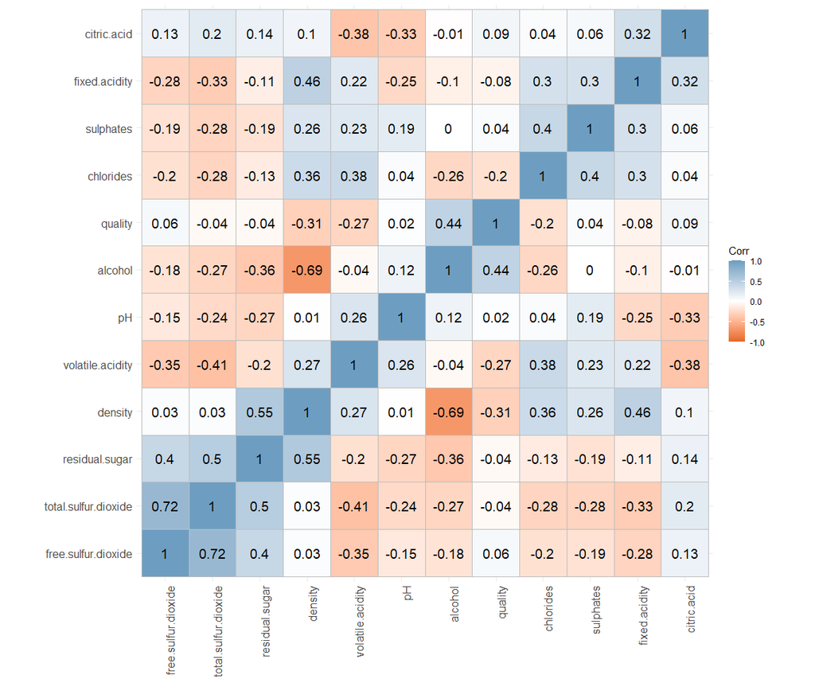

```r
#Remove non numeric data
a<- wine%>%
  select(-wine_type)

#Calculate Correlation
pearson_cor<- cor(a,use="everything", method="pearson")
# Plot
ggcorrplot(pearson_cor, type="full",
           hc.method = "hclust",
           hc.order=TRUE,
           lab=TRUE,lab_size = 5,
           insig="blank",
           tl.cex = 12,tl.col="blue",tl.srt = 90,
           colors = c("#E46726","white","#6D9EC1"))
```

```r
# Remove temporaty variables
rm(a,pearson_cor)
```

The correlation plot indicates the presence of moderate co-linearity between alcohol and density and free and total sulfur dioxide.

The quality grade does not show a strong linear correlation with any of the numeric predictors. Moderate correlation with alcohol.

### 3.3.2 Non-linear Bi-Variate correlation : Spearman

The spearman correlation is just used to understand if there will be any non-linear correlation between pair of variables. The results do not differ much from the linear correlation

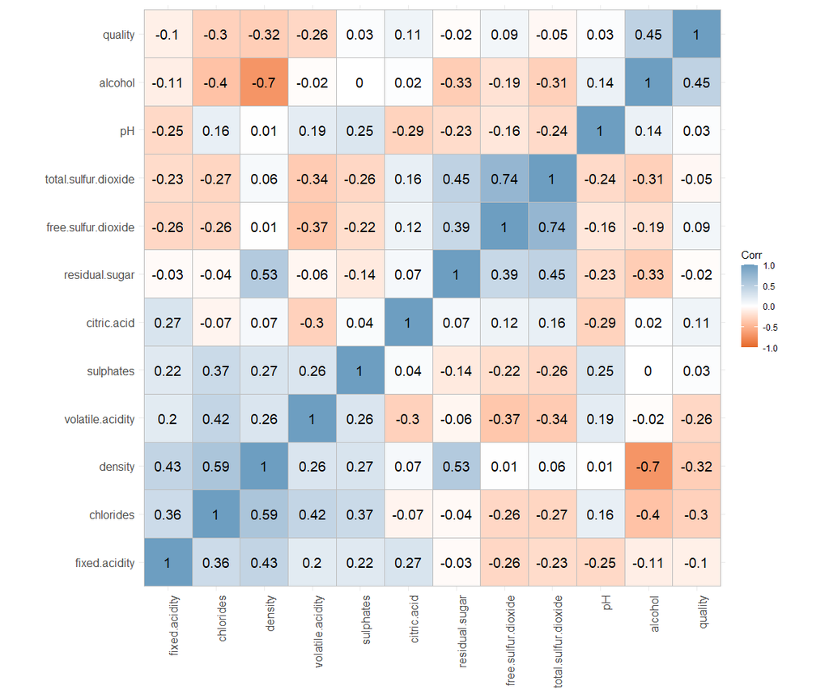

```r
#Remove non numeric data
a<- wine%>%
  select(-wine_type)

#Calculate Correlation
spearman_cor<- cor(a,use="everything", method="spearman")
# Plot
ggcorrplot(spearman_cor, type="full",
           hc.method = "hclust",
           hc.order=TRUE,
           lab=TRUE,lab_size = 5,
           insig="blank",
           tl.cex = 12,tl.col="blue",tl.srt = 90,
           colors = c("#E46726","white","#6D9EC1"))
```

```r
# Remove temporaty variables
rm(a,spearman_cor)
```

# 4 Modelling approaches

The response variable (quality) is an ordered integer from subjective measurement, therefore the problem fall into the classification range and classification models will be used to predict the result.

For classification methods, some evaluations can be used:

- Misclassification
  - The overall error. Number of wrong classification divided by the total observations
- Accuracy
  - How often is the classifier correct
  - (TP + TN) / Total
- Precision
  - How accurate the classifier predict events
  - Maximize True positives to False positives ratio *TP/(TP+FP)
- Sensitivity
  - How accurate the classifier classify actual events
  - Ability of an algorithm to predict a positive outcome when the actual outcome is positive
  - TP/(TP+FN)
- Specificity
  - How accurate the classifier classify non-events *Ability of an algorithm to not predict a positive outcome when the actual outcome is not positive
  - TN/(TN+FP)

It is important to highlight that due to low prevalence it is possible to have high accuracy and low sensitivity, therefore a good balance between sensitivity and specificity shall be targeted as well, together with high accuracy (or low misclassification).

## 4.1 Training & Testing data

The combined table (with red and white wine) will be used as the basis for modelling.

The data will be split into training and testing data set in the proportion of 70/30 (70% of the data to training and 30% of the data to testing)

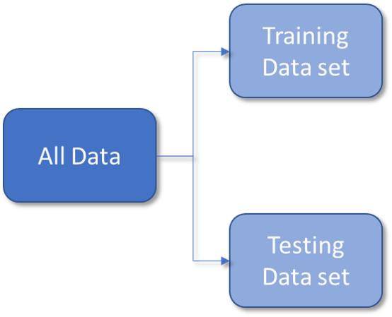

Training & Testing data sets

The models will be build on the training data set and validated with the unseen data represented by the testing data set.

Due to the unbalanced data, the split will be done with sample stratification with wine quality as basis.

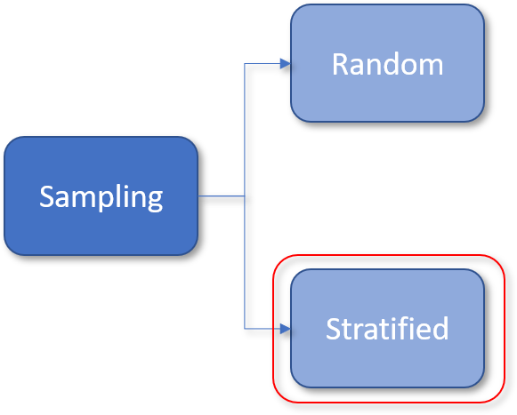

Two main splitting strategies

```r
# The response variable is integer. It will be transformed into factors
wine_factor <- wine%>%
  mutate(quality=factor(quality))
levels(wine_factor$quality)
```

```
[1] "3" "4" "5" "6" "7" "8" "9"
```

```r
# package used for stratified sampling = rsample
# Stratification based on wine quality due to the unbalanced data
set.seed(1234) # For reproducibility
data_split <- initial_split(wine_factor, prop=0.7, strata = quality)
training_dt <- training(data_split)
testing_dt <- testing(data_split)

# Comparing training , testing and wine table for wine type
a <- rbind(wine=prop.table(table(wine_factor$wine_type)),
           training=prop.table(table(training_dt$wine_type)),
           testing=prop.table(table(testing_dt$wine_type)))

kable(a,align="c", "html", booktabs=TRUE, caption = "Data splitting stratification",digits = 2)%>%
  kable_styling(bootstrap_options ="striped", full_width = TRUE, position = "center", fixed_thead = T, font_size = 10)%>%
  row_spec(row=0,angle=0,color="steelblue", bold=T)
```

Data splitting stratification

|  | red_wine | white_wine |
| --- | --- | --- |
| wine | 0.25 | 0.75 |
| training | 0.25 | 0.75 |
| testing | 0.24 | 0.76 |

```r
# Comparing training , testing and wine table for wine quality
b<- rbind(wine=prop.table(table(wine_factor$quality)),
           training=prop.table(table(training_dt$quality)),
           testing=prop.table(table(testing_dt$quality)))

kable(b,align="c", "html", booktabs=TRUE, caption = "Data splitting stratification",digits = 3)%>%
  kable_styling(bootstrap_options ="striped", full_width = TRUE, position = "center", fixed_thead = T, font_size = 10)%>%
  row_spec(row=0,angle=0,color="steelblue", bold=T)
```

Data splitting stratification

|  | 3 | 4 | 5 | 6 | 7 | 8 | 9 |
| --- | --- | --- | --- | --- | --- | --- | --- |
| wine | 0.005 | 0.033 | 0.329 | 0.437 | 0.166 | 0.030 | 0.001 |
| training | 0.004 | 0.035 | 0.330 | 0.435 | 0.166 | 0.029 | 0.001 |
| testing | 0.007 | 0.029 | 0.327 | 0.439 | 0.166 | 0.031 | 0.001 |

```r
#Temporary files are removed
rm(a,b,data_split)
```

The stratification table shows a comparison of prevalence for the response variable. It is clear that the data set presents unbalanced distribution (e.g there is much more wines classified as quality 6, than quality 3)

## 4.2 Re-sampling

Splitting the training data set into more parts can be used to improve the performance in the training data set

The K-fold cross-validation (k-fold CV) is a re-sampling methods that randomly divides the training data into k groups of equal sizes. One of the groups is used than to compute the model performance. This process is repeated k times, resulting in k estimates of the error. The average of the k estimates provides an approximation of the error we might expect on unseen data.

As an alternative, a bootstrap sampling can also be used to estimate an approximation of the error in the training data set.

# 5 Models

## 5.1 Base Model

The base model is the reference one which will be used as basis for comparison. In this case the models used as reference is the probability of the most common class in the training data set.

```r
# Create a probability table and round it to 3 digits
a<- round(prop.table(table(training_dt$quality)),3)
# Combine table with class lables
b<- as_tibble(cbind(class=names(table(training_dt$quality)),distribution=a))
# Print it nicely
kable(b,align="c", "html", booktabs=TRUE, caption = "Training data set - Class distribution",digits = 2)%>%
  kable_styling(bootstrap_options ="striped", full_width = FALSE, position = "center", fixed_thead = T, font_size = 10)%>%
  row_spec(row=0,angle=0,color="steelblue", bold=T)
```

Training data set - Class distribution

| class | distribution |
| --- | --- |
| 3 | 0.004 |
| 4 | 0.035 |
| 5 | 0.33 |
| 6 | 0.435 |
| 7 | 0.166 |
| 8 | 0.029 |
| 9 | 0.001 |

```r
## Define the Main Class
max_i <- which.max(b$distribution)
b[max_i,]
```

| class | distribution |
| --- | --- |
| 6 | 0.435 |

## 5.2 Testing data set

```r
# Calculation the prediction using the model and the testing data set
y_hat <- rep(b[max_i,1],nrow(testing_dt)) # Use main class response as the prediction for the testing data set
#Confusion matrix, comparing the prediction and the real results
cm <- confusionMatrix(factor(y_hat), testing_dt$quality) # y_hat needs to be converted to factor
```

```
Levels are not in the same order for reference and data. Refactoring data to match.
```

```r
cm
```

```
Confusion Matrix and Statistics

          Reference
Prediction   3   4   5   6   7   8   9
         3   0   0   0   0   0   0   0
         4   0   0   0   0   0   0   0
         5   0   0   0   0   0   0   0
         6  13  57 637 856 323  61   1
         7   0   0   0   0   0   0   0
         8   0   0   0   0   0   0   0
         9   0   0   0   0   0   0   0

Overall Statistics

               Accuracy : 0.4394
                 95% CI : (0.4172, 0.4618)
    No Information Rate : 0.4394
    P-Value [Acc > NIR] : 0.5087

                  Kappa : 0

 Mcnemar's Test P-Value : NA

Statistics by Class:

                     Class: 3 Class: 4 Class: 5 Class: 6 Class: 7
Sensitivity          0.000000  0.00000    0.000   1.0000   0.0000
Specificity          1.000000  1.00000    1.000   0.0000   1.0000
Pos Pred Value            NaN      NaN      NaN   0.4394      NaN
Neg Pred Value       0.993326  0.97074    0.673      NaN   0.8342
Prevalence           0.006674  0.02926    0.327   0.4394   0.1658
Detection Rate       0.000000  0.00000    0.000   0.4394   0.0000
Detection Prevalence 0.000000  0.00000    0.000   1.0000   0.0000
Balanced Accuracy    0.500000  0.50000    0.500   0.5000   0.5000
                     Class: 8  Class: 9
Sensitivity           0.00000 0.0000000
Specificity           1.00000 1.0000000
Pos Pred Value            NaN       NaN
Neg Pred Value        0.96869 0.9994867
Prevalence            0.03131 0.0005133
Detection Rate        0.00000 0.0000000
Detection Prevalence  0.00000 0.0000000
Balanced Accuracy     0.50000 0.5000000
```

```r
Accu_test_base <-cm$overall["Accuracy"]
kappa_test_base <-cm$overall["Kappa"]
#remove Temporary files
rm(y_hat,cm,a,b,max_i)
```

## 5.3 K nearest neighbors (Knn)

The Knn algorithm identifies k observations that are similar or nearest to the new record being predicted and than uses the average response value (regression) or the most common class (classification)

The Knn method depends on the distance between the samples, the scale of the predictors can have influence on the distances among the samples, therefore the predictors shall be pre-processed in the model preparation (centralized and scaled).

```r
## The Knn model has the following parameters to fine tune
getModelInfo("knn")[[2]]$parameters
```

| parameter | class | label |
| --- | --- | --- |
| k | numeric | #Neighbors |

```r
# Resampling Strategy
cv <- trainControl(
  method="repeatedcv",
  number=10,
  repeats=5)
# Grid to fine tune hyperparameter
hyper_grid_knn<- expand.grid(k=seq(1,15,by=1))
```

```r
# Tune the Knn model using the training data set
knn_fit <- train(
  quality~.,# quality is the response and all other parameters are predictors
  data=training_dt,
  method="knn",
  preProcess=c("center","scale"),
  trControl=cv,
  tuneGrid=hyper_grid_knn)
```

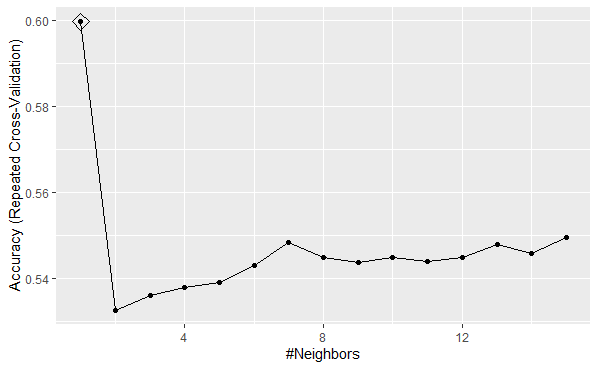

```r
# Plot the fine tuning
ggplot(knn_fit,highlight = TRUE)
```

```r
# results for the optimal k
knn_fit$bestTune
```

|  | k |
| --- | --- |
| 1 | 1 |

```r
knn_fit
```

```
k-Nearest Neighbors

4549 samples
  12 predictor
   7 classes: '3', '4', '5', '6', '7', '8', '9'

Pre-processing: centered (12), scaled (12)
Resampling: Cross-Validated (10 fold, repeated 5 times)
Summary of sample sizes: 4095, 4094, 4093, 4092, 4093, 4095, ...
Resampling results across tuning parameters:

  k   Accuracy   Kappa
   1  0.5997756  0.4030740
   2  0.5327726  0.3022558
   3  0.5362073  0.2998680
   4  0.5379652  0.2990383
   5  0.5392011  0.2964600
   6  0.5431600  0.2991043
   7  0.5485664  0.3051599
   8  0.5448746  0.2976104
   9  0.5439048  0.2928399
  10  0.5450930  0.2933589
  11  0.5441691  0.2905914
  12  0.5449159  0.2909842
  13  0.5479023  0.2936767
  14  0.5458412  0.2885624
  15  0.5495329  0.2937744

Accuracy was used to select the optimal model using the largest value.
The final value used for the model was k = 1.
```

```r
# best performing model
knn_fit$finalModel
```

```
1-nearest neighbor model
Training set outcome distribution:

   3    4    5    6    7    8    9
  17  159 1501 1980  756  132    4
```

The best results if for k=1. This is an extreme case, because the prediction is based on a single observation that has the closest distance to measure and there is a risk to be over fitting the model.

### 5.3.1 Testing Data set

The testing set performs better when the best fit results in the training set are applied achieving the best results for accuracy, balanced accuracy (therefore sensitivity and specificity) and Kappa value.

```r
# Calculation the prediction using the model and the testing data set
y_hat <- predict(knn_fit,testing_dt,type="raw")
#Confusion matrix, comparing the prediction and the real results
cm <- confusionMatrix(y_hat, testing_dt$quality)
cm
```

```
Confusion Matrix and Statistics

          Reference
Prediction   3   4   5   6   7   8   9
         3   0   0   2   0   0   0   0
         4   2  13  24  17   2   0   0
         5   4  24 396 158  24   1   0
         6   6  16 188 569  96  13   0
         7   1   3  25  94 184  23   1
         8   0   1   2  18  17  24   0
         9   0   0   0   0   0   0   0

Overall Statistics

               Accuracy : 0.6088
                 95% CI : (0.5868, 0.6306)
    No Information Rate : 0.4394
    P-Value [Acc > NIR] : < 2.2e-16

                  Kappa : 0.4142

 Mcnemar's Test P-Value : NA

Statistics by Class:

                     Class: 3 Class: 4 Class: 5 Class: 6 Class: 7
Sensitivity          0.000000 0.228070   0.6217   0.6647  0.56966
Specificity          0.998966 0.976203   0.8391   0.7079  0.90954
Pos Pred Value       0.000000 0.224138   0.6524   0.6408  0.55589
Neg Pred Value       0.993320 0.976720   0.8203   0.7292  0.91404
Prevalence           0.006674 0.029261   0.3270   0.4394  0.16581
Detection Rate       0.000000 0.006674   0.2033   0.2921  0.09446
Detection Prevalence 0.001027 0.029774   0.3116   0.4559  0.16992
Balanced Accuracy    0.499483 0.602137   0.7304   0.6863  0.73960
                     Class: 8  Class: 9
Sensitivity           0.39344 0.0000000
Specificity           0.97986 1.0000000
Pos Pred Value        0.38710       NaN
Neg Pred Value        0.98038 0.9994867
Prevalence            0.03131 0.0005133
Detection Rate        0.01232 0.0000000
Detection Prevalence  0.03183 0.0000000
Balanced Accuracy     0.68665 0.5000000
```

```r
Accu_test_knn <-cm$overall["Accuracy"]
kappa_test_Knn <-cm$overall["Kappa"]
#remove Temporary files
rm(y_hat)
```

```r
# By class
cm$byClass[,c(1:2,8)]
```

```
         Sensitivity Specificity  Prevalence
Class: 3   0.0000000   0.9989664 0.006673511
Class: 4   0.2280702   0.9762031 0.029260780
Class: 5   0.6216641   0.8390542 0.327002053
Class: 6   0.6647196   0.7078755 0.439425051
Class: 7   0.5696594   0.9095385 0.165811088
Class: 8   0.3934426   0.9798622 0.031314168
Class: 9   0.0000000   1.0000000 0.000513347
```

```r
# Remove temporary variables
rm(cm)
```

### 5.3.2 Results from Knn model

The overall accuracy rate is not very impressive, but still the model is able to predict correctly more than 60% of data set.

The no information rate is the best guess given no information beyond the overall distribution of the classes.

The overall accuracy is higher than the no information date, therefore the model is working better than a best guess.

The Kappa ranges from 0 to 1 and measures the agreement between the model’s prediction and the real one. The Kappa value is in the middle third (above 33% and below 66%) of the range, indicating that the model’s agreement is moderate, most likely due to unbalanced classes.

the summary for the Knn method follows: * Overall accuracy higher than no Information rate * Unbalanced multi class response

## 5.4 Classification Tree

Tree-based models are a class of non-parametric algorithms that work by partitioning the predictors space into a number of smaller regions using a set of splitting rules. The partitioning process for classification problems works towards homogeneity of the categories measured either by the entropy or the Gini index. In a perfect scenario, both indexes tend to zero.

```r
## The tree model has the following parameters to fine tune
getModelInfo("rpart")[[5]]$parameters
```

| parameter | class | label |
| --- | --- | --- |
| cp | numeric | Complexity Parameter |
| split | character | Split Function |
| prune | character | Pruning Measure |

The tree can be stopped by setting the depth (number of levels the tree can grow) forcing an early stop.

the rpart package automatically applies a range of cp and performs 10-fold CV by default.

A tentative to run the tree models with the default parameters for the rpart resulted in a accuracy lower than the Knn model.

To try to improve the model the complexity parameter will be forces to zero and the tree will be pruned based on the defined cp

```r
# Set cp=0 and let the tree grow
tree_fit<-rpart(formula=quality~.,
                data=training_dt,
                control =list(cp=0,xval=10))
```

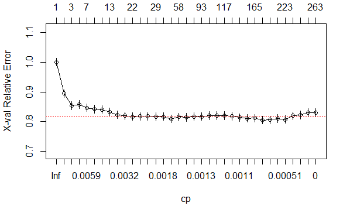

```r
# Plot cp to define the optimal size
plotcp(tree_fit,col=2,upper="size")
```

```r
# print cp table for reference
tree_fit$cptable
```

```
             CP nsplit rel error    xerror       xstd
1  0.1066562865      0 1.0000000 1.0000000 0.01301645
2  0.0548851693      1 0.8933437 0.8949007 0.01312619
3  0.0083690152      2 0.8384585 0.8540288 0.01311873
4  0.0068119891      4 0.8217205 0.8579214 0.01312064
5  0.0050603348      6 0.8080965 0.8470222 0.01311464
6  0.0044764500      7 0.8030362 0.8423511 0.01311145
7  0.0042818217      9 0.7940833 0.8411833 0.01311060
8  0.0038925652     12 0.7812378 0.8322304 0.01310329
9  0.0032697548     13 0.7773453 0.8232775 0.01309464
10 0.0031140522     19 0.7574932 0.8197742 0.01309088
11 0.0027247956     21 0.7512651 0.8170494 0.01308782
12 0.0025301674     24 0.7430907 0.8182172 0.01308914
13 0.0023355391     26 0.7380304 0.8178279 0.01308870
14 0.0019462826     28 0.7333593 0.8166602 0.01308737
```

[output cut: 21 more lines]

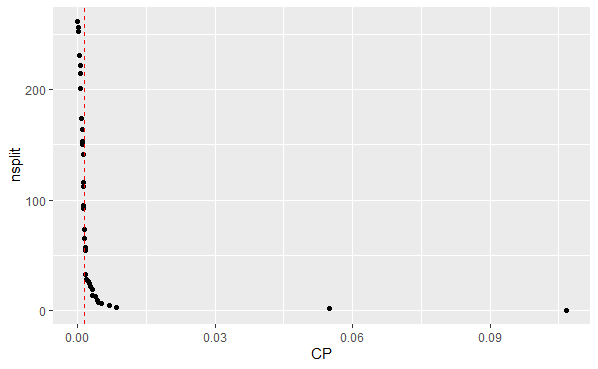

```r
# plot the a chart marking the chosen cp
data.frame(tree_fit$cptable)%>%
  ggplot(aes(x=CP,y=nsplit), highlight=TRUE)+
  geom_point()+
  geom_vline(xintercept = 0.0015, linetype="dashed",colour="red")
```

```r
# Using the defined cp, recalculate the model
tree_fit<-rpart(formula=quality~.,
                data=training_dt,
                cp=0.0015)
```

Due to the tree size the following plot is just illustrative

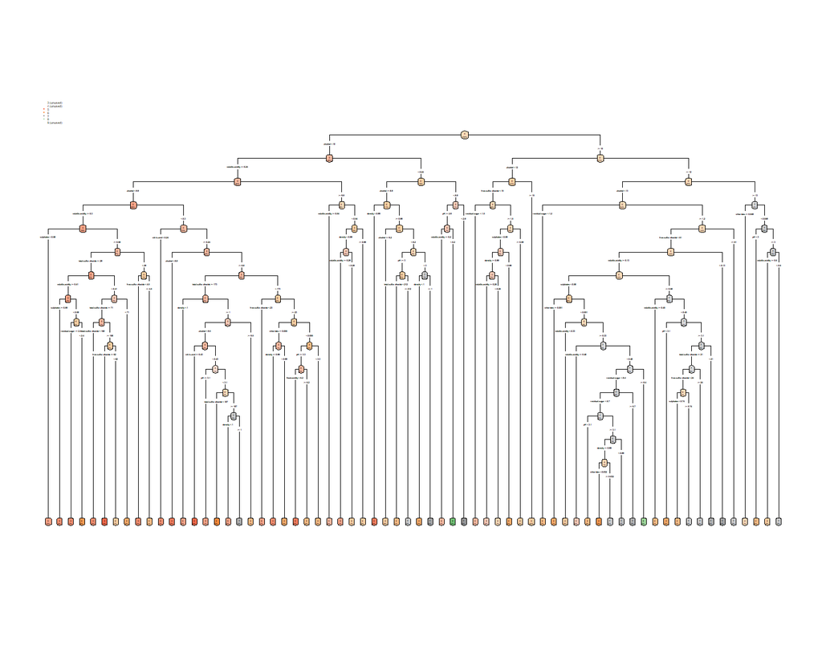

```r
rpart.plot(tree_fit,type=4,extra=100)
```

### 5.4.1 Testing Data set

```r
# Calculation of the prediction using the model and the testing data set
y_hat <- predict(tree_fit,testing_dt,type="class")
#Confusion matrix, comparing the prediction and the real results
cm <- confusionMatrix(y_hat, testing_dt$quality)
cm
```

```
Confusion Matrix and Statistics

          Reference
Prediction   3   4   5   6   7   8   9
         3   0   0   0   0   0   0   0
         4   0   0   0   0   0   0   0
         5   8  38 378 166  18   4   0
         6   5  18 249 633 222  34   0
         7   0   1   6  51  82  20   1
         8   0   0   4   6   1   3   0
         9   0   0   0   0   0   0   0

Overall Statistics

               Accuracy : 0.5626
                 95% CI : (0.5403, 0.5848)
    No Information Rate : 0.4394
    P-Value [Acc > NIR] : < 2.2e-16

                  Kappa : 0.2962

 Mcnemar's Test P-Value : NA

Statistics by Class:

                     Class: 3 Class: 4 Class: 5 Class: 6 Class: 7
Sensitivity          0.000000  0.00000   0.5934   0.7395  0.25387
Specificity          1.000000  1.00000   0.8215   0.5165  0.95138
Pos Pred Value            NaN      NaN   0.6176   0.5452  0.50932
Neg Pred Value       0.993326  0.97074   0.8061   0.7166  0.86514
Prevalence           0.006674  0.02926   0.3270   0.4394  0.16581
Detection Rate       0.000000  0.00000   0.1940   0.3249  0.04209
Detection Prevalence 0.000000  0.00000   0.3142   0.5960  0.08265
Balanced Accuracy    0.500000  0.50000   0.7075   0.6280  0.60263
                     Class: 8  Class: 9
Sensitivity          0.049180 0.0000000
Specificity          0.994171 1.0000000
Pos Pred Value       0.214286       NaN
Neg Pred Value       0.970010 0.9994867
Prevalence           0.031314 0.0005133
Detection Rate       0.001540 0.0000000
Detection Prevalence 0.007187 0.0000000
Balanced Accuracy    0.521675 0.5000000
```

```r
Accu_test_tree <-cm$overall["Accuracy"]
kappa_test_tree <-cm$overall["Kappa"]
# By class
cm$byClass[,c(1:2,8)]
```

```
         Sensitivity Specificity  Prevalence
Class: 3  0.00000000   1.0000000 0.006673511
Class: 4  0.00000000   1.0000000 0.029260780
Class: 5  0.59340659   0.8215103 0.327002053
Class: 6  0.73948598   0.5164835 0.439425051
Class: 7  0.25386997   0.9513846 0.165811088
Class: 8  0.04918033   0.9941706 0.031314168
Class: 9  0.00000000   1.0000000 0.000513347
```

```r
# Remove temporary variables
rm(cm,y_hat)
```

### 5.4.2 Feature interpretation

The alcohol level, as observed in the EDA, is the most important predictor for the final classification when using the single tree model

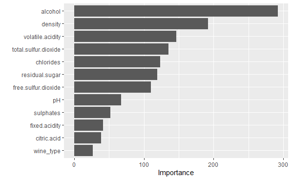

```r
vip(tree_fit, num_features = 12)
```

```r
# Plot all 12 features
```

## 5.5 Bagging

The bagging model create a defined number of bootstrap samples from the original training data using OOB re-sampling by default. Bagging aggregates the predictions across all trees, reducing the variance of the overall procedure improving the prediction performance.

```r
# Set the number of trees to fine tune
ntree=c(10,25,50,100,150,200,250,300)

# create empty vector to store OOB error values
misclassification_error <- vector(mode = "numeric", length = length(ntree))

for (i in seq_along(ntree) ){
  # set seed
set.seed(1234)
  #train bagged model
m <- bagging(formula=quality~.,
                    data= training_dt,
                    nbagg=ntree[i],
                    coob=TRUE,
                    control=rpart.control(minsplit=2,cp=0))# No prunning + requires just teo observations in a node to split
misclassification_error[i] <-m$err
}
```

```r
# Make a table for the tree sizes
a<- as_tibble(cbind(ntree,misclassification_error))
#print the table
kable(a,align="c", "html", booktabs=TRUE, caption = "Number of bagged trees fine tuning",digits = 3)%>%
  kable_styling(bootstrap_options ="striped", full_width = TRUE, position = "center", fixed_thead = T, font_size = 10)%>%
  row_spec(row=0,angle=0,color="steelblue", bold=T)
```

Number of bagged trees fine tuning

| ntree | misclassification_error |
| --- | --- |
| 10 | 0.427 |
| 25 | 0.368 |
| 50 | 0.353 |
| 100 | 0.347 |
| 150 | 0.338 |
| 200 | 0.332 |
| 250 | 0.332 |
| 300 | 0.330 |

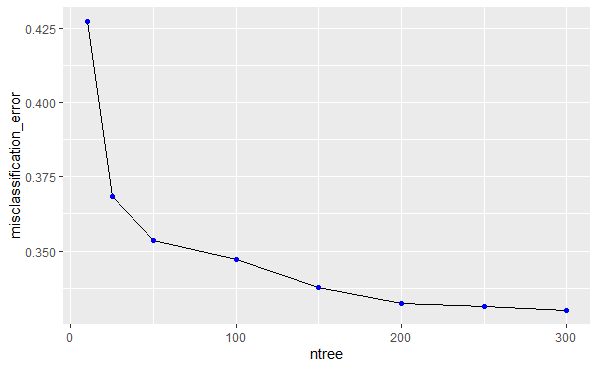

```r
#plot the chart
a%>%
  ggplot(aes(y=misclassification_error,x=ntree))+
  geom_line()+
  geom_point(colour="blue")
```

```r
#Remove temporary files
rm(a)
```

The results above 200 trees are marginal.

```r
wine_bag <- bagging(formula=quality~.,
                    data=training_dt,
                    nbagg=300,
                    coob=TRUE,
                    control=rpart.control(minsplit=2,cp=0)
                    )
```

```r
# print bagging results
wine_bag
```

```
Bagging classification trees with 300 bootstrap replications

Call: bagging.data.frame(formula = quality ~ ., data = training_dt,
    nbagg = 300, coob = TRUE, control = rpart.control(minsplit = 2,
        cp = 0))

Out-of-bag estimate of misclassification error:  0.3355
```

### 5.5.1 Testing Data set

```r
# Calculation of the prediction using the model and the testing data set
y_hat <- predict(wine_bag,
                 testing_dt,
                 type="class")
#Confusion matrix, comparing the prediction and the real results
cm <- confusionMatrix(data=y_hat,
                      reference=testing_dt$quality)
```

```
longer object length is not a multiple of shorter object lengthLevels are not in the same order for reference and data. Refactoring data to match.
```

```r
cm
```

```
Confusion Matrix and Statistics

          Reference
Prediction   3   4   5   6   7   8   9
         3   0   0   0   0   0   0   0
         4   0   8   2   4   0   0   0
         5   8  34 456 139  14   2   0
         6   5  14 174 659 148  19   0
         7   0   1   5  53 161  20   1
         8   0   0   0   1   0  20   0
         9   0   0   0   0   0   0   0

Overall Statistics

               Accuracy : 0.6694
                 95% CI : (0.648, 0.6903)
    No Information Rate : 0.4394
    P-Value [Acc > NIR] : < 2.2e-16

                  Kappa : 0.483

 Mcnemar's Test P-Value : NA

Statistics by Class:

                     Class: 3 Class: 4 Class: 5 Class: 6 Class: 7
Sensitivity          0.000000 0.140351   0.7159   0.7699  0.49845
Specificity          1.000000 0.996827   0.8497   0.6703  0.95077
Pos Pred Value            NaN 0.571429   0.6983   0.6467  0.66805
Neg Pred Value       0.993326 0.974664   0.8602   0.7879  0.90510
Prevalence           0.006674 0.029261   0.3270   0.4394  0.16581
Detection Rate       0.000000 0.004107   0.2341   0.3383  0.08265
Detection Prevalence 0.000000 0.007187   0.3352   0.5231  0.12372
Balanced Accuracy    0.500000 0.568589   0.7828   0.7201  0.72461
                     Class: 8  Class: 9
Sensitivity           0.32787 0.0000000
Specificity           0.99947 1.0000000
Pos Pred Value        0.95238       NaN
Neg Pred Value        0.97872 0.9994867
Prevalence            0.03131 0.0005133
Detection Rate        0.01027 0.0000000
Detection Prevalence  0.01078 0.0000000
Balanced Accuracy     0.66367 0.5000000
```

```r
Accu_test_bag <-cm$overall["Accuracy"]
kappa_test_bag <-cm$overall["Kappa"]
# By class
cm$byClass[,c(1:2,8)]
```

```
         Sensitivity Specificity  Prevalence
Class: 3   0.0000000   1.0000000 0.006673511
Class: 4   0.1403509   0.9968271 0.029260780
Class: 5   0.7158556   0.8497330 0.327002053
Class: 6   0.7698598   0.6703297 0.439425051
Class: 7   0.4984520   0.9507692 0.165811088
Class: 8   0.3278689   0.9994701 0.031314168
Class: 9   0.0000000   1.0000000 0.000513347
```

```r
# Remove temporary variables
rm(cm,y_hat)
```

The bagged tree model improves quite considerably the results when compared to Knn and classification tree.

### 5.5.2 Feature interpretation

```r
wine_bag_b
```

```
Bagged CART

4549 samples
  12 predictor
   7 classes: '3', '4', '5', '6', '7', '8', '9'

No pre-processing
Resampling: Bootstrapped (25 reps)
Summary of sample sizes: 4549, 4549, 4549, 4549, 4549, 4549, ...
Resampling results:

  Accuracy   Kappa
  0.6032409  0.3852447
```

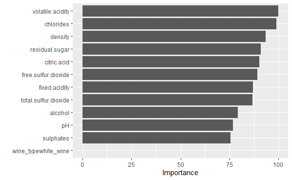

```r
vip(wine_bag_b,num_features = 12)
```

With bagged trees, the importance of variables has changed quite considerably.

## 5.6 Random forests

The random forest models will inject randomness into the tree-growing process. During the bagging process, random forests perform a split-variable randomization to a limited number of predictors (mtry)

```r
wine_rf <-randomForest(quality~.,data=training_dt,
                       mtry=2,
                       ntree=500)
wine_rf
```

```
Call:
 randomForest(formula = quality ~ ., data = training_dt, mtry = 2,      ntree = 500)
               Type of random forest: classification
                     Number of trees: 500
No. of variables tried at each split: 2

        OOB estimate of  error rate: 33.08%
Confusion matrix:
  3  4    5    6   7  8 9 class.error
3 0  1   10    6   0  0 0   1.0000000
4 1 12   88   57   1  0 0   0.9245283
5 0  4 1057  429  11  0 0   0.2958028
6 0  0  323 1551 105  1 0   0.2166667
7 0  0   16  358 378  4 0   0.5000000
8 0  0    1   46  39 46 0   0.6515152
9 0  0    0    2   2  0 0   1.0000000
```

### 5.6.1 Testing Data set

```r
# Calculation of the prediction using the model and the testing data set
y_hat <- predict(wine_rf,
                 testing_dt,
                 type="class")
#Confusion matrix, comparing the prediction and the real results
cm <- confusionMatrix(data=y_hat,
                      reference=testing_dt$quality)
cm
```

```
Confusion Matrix and Statistics

          Reference
Prediction   3   4   5   6   7   8   9
         3   0   0   0   0   0   0   0
         4   0   8   0   2   0   0   0
         5   6  31 454 118   8   1   0
         6   7  17 179 696 152  22   0
         7   0   1   4  40 163  19   1
         8   0   0   0   0   0  19   0
         9   0   0   0   0   0   0   0

Overall Statistics

               Accuracy : 0.6879
                 95% CI : (0.6668, 0.7084)
    No Information Rate : 0.4394
    P-Value [Acc > NIR] : < 2.2e-16

                  Kappa : 0.508

 Mcnemar's Test P-Value : NA

Statistics by Class:

                     Class: 3 Class: 4 Class: 5 Class: 6 Class: 7
Sensitivity          0.000000 0.140351   0.7127   0.8131  0.50464
Specificity          1.000000 0.998942   0.8749   0.6548  0.96000
Pos Pred Value            NaN 0.800000   0.7346   0.6486  0.71491
Neg Pred Value       0.993326 0.974716   0.8624   0.8171  0.90698
Prevalence           0.006674 0.029261   0.3270   0.4394  0.16581
Detection Rate       0.000000 0.004107   0.2331   0.3573  0.08368
Detection Prevalence 0.000000 0.005133   0.3172   0.5508  0.11704
Balanced Accuracy    0.500000 0.569647   0.7938   0.7339  0.73232
                     Class: 8  Class: 9
Sensitivity          0.311475 0.0000000
Specificity          1.000000 1.0000000
Pos Pred Value       1.000000       NaN
Neg Pred Value       0.978227 0.9994867
Prevalence           0.031314 0.0005133
Detection Rate       0.009754 0.0000000
Detection Prevalence 0.009754 0.0000000
Balanced Accuracy    0.655738 0.5000000
```

```r
Accu_test_rf <-cm$overall["Accuracy"]
kappa_test_rf<-cm$overall["Kappa"]
# By class
cm$byClass[,c(1:2,8)]
```

```
         Sensitivity Specificity  Prevalence
Class: 3   0.0000000   1.0000000 0.006673511
Class: 4   0.1403509   0.9989424 0.029260780
Class: 5   0.7127159   0.8749047 0.327002053
Class: 6   0.8130841   0.6547619 0.439425051
Class: 7   0.5046440   0.9600000 0.165811088
Class: 8   0.3114754   1.0000000 0.031314168
Class: 9   0.0000000   1.0000000 0.000513347
```

```r
# Remove temporary variables
rm(cm,y_hat)
```

### 5.6.2 Feature interpretation

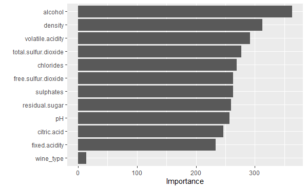

```r
vip(wine_rf,num_features = 12)
```

# 6 Results

The comparison of the Overall accuracy for the tested classification models on the testing data set follows:

```r
#Building accuracy camparison table
model_names <-c("Base","Knn","Classification_tree","Bagging","Random_Forest")

## Overall Accuracy
accuracy_values <-c(Accu_test_base,Accu_test_knn,Accu_test_tree,Accu_test_bag,Accu_test_rf)
accuracy_values <- round(accuracy_values,3)

## Kappa index
kappa_values <-c(kappa_test_base,kappa_test_Knn,kappa_test_tree,kappa_test_bag,kappa_test_rf)
kappa_values <- round(kappa_values,3)

## Combine the tables
accuracy_test_set <- as_tibble(cbind(model_names,accuracy_values,kappa_values))
a<-accuracy_test_set %>%
  mutate(accuracy_improvement = (as.numeric(accuracy_values)-as.numeric(Accu_test_base)))%>%
  arrange(desc(accuracy_values))


## print the table
kable(a,align="l", "html", booktabs=TRUE, caption = "Comparison table - Models performance in the testing data set",digits = 3)%>%
  kable_styling(bootstrap_options ="striped", full_width = TRUE, position = "center", fixed_thead = T, font_size = 10)%>%
  row_spec(row=0,angle=0,color="steelblue", bold=T)
```

Comparison table - Models performance in the testing data set

| model_names | accuracy_values | kappa_values | accuracy_improvement |
| --- | --- | --- | --- |
| Random_Forest | 0.688 | 0.508 | 0.249 |
| Bagging | 0.669 | 0.483 | 0.230 |
| Knn | 0.609 | 0.414 | 0.170 |
| Classification_tree | 0.563 | 0.296 | 0.124 |
| Base | 0.439 | 0 | 0.000 |

```r
#Removing temporary files
rm(model_names,accuracy_values,accuracy_test_set,a)
```

Accuracy is not the only parameter to be observed. The problem presents a multi-class , unbalanced reponse variables therefore the balanced accuracy, which takes into consideration sensitivty and specificity is also observed for each indivual class.

The top 5 predictors for the the wine quality were in line with the EDA step

1. Alcohol
2. Density
3. Volatile acidity
4. Total sulfur
5. Chlorides

surprisingly , the type of wine (red or white) does not have important impact on the predictions, showing that the difference in the distribution can be related to the number of white and red wine analyzed.

# 7 Conclusion

Although the best tested model promotes a considerable increment in the performance when compared to the baseline, the data set imposes some restrictions to the performance since not all classes from this multi-class problem are covered and the ones present in the data set are highly unbalanced. The models fail on correctly predict the extreme grades (Very bad and excellent) due to those restrictions. The boundaries of the models will be always between class 3 and class 9, tending to make better predictions to the middle classes.

The excercise also makes evident the powder of aggregated predictions, with Bagging and random forests performing far better the the other tested models, at the cost of computational speed. Nevertheless the bagging algorithim resulted in a variable importance which is not aligned with the observations from the EDA step. The random forest algortithim form the other hands is pretty much aligned with the visualization, therefore should the the preferred one chosen, among all the tested models, for the wine quality prediction.

# 8 Bibliography

1. Rafael A. Irizarry (2019), Introduction to Data Science : Data Analysis and Prediction Algorithms with R, CRC Press
2. Gareth James,Daniela Witten, Trevor Hastie & Robert Tibshirani (2013), An introduction to statistical learning with applications in R, Springer
3. Bradley Boehmke and Brandon Greenwell (2020), Hands-On machine learning with R, CRC Press
4. Brett Lantz (2019), Machine learning with R : Expert techniques for predictive modellin, Packt
5. Hadley Wickham (2016), ggplot2: Elegant Graphics for Data Analysis, Springer